# Schonfeld Case-Study

Luis Felipe Lins

In this case study, I was asked to write a working pipeline to pull data from SEC's EDGAR data on 13F fillings, construct positioning factors for a selected universe of possible assets (identified here by CUSIP codes) and investment managers (identified here by CIK codes), and backtest these possible factors performance.

This notebook will present the full pipeline to do this analysis. It will use functions defined in other .py scripts, such as get_data.py, factors.py and trading_strategy.py. In the next lines, I'll explain in detail the process behind each part of the code.

The main factor I intend to present is a centrality measure. With the universe of managers and assets under consideration, we can think that different managers may share similar positions, while some positions are held mostly by a couple of managers. In this sense, assets held in similar size by all of the managers are more central in a network of assets, while assets held differently among managers is less central. We therefore construct a centrality factor, measuring how common the size of the holding of an asset is among managers. The predictive power is expected to come from the following. When every manager holds a stock at roughly the same weight, no single manager's decision defines the position of the group as a whole (high centrality, low factor value). When managers hold the same stock but at different weights (e.g. one at 5% of its book, another at 0.5%) the stock's ownership is dominated by whoever took the largest bet, and its price is more exposed to what that group does next (low centrality, high factor value).

To compare this new factor to other common factors, I'll also calculate three positioning factors serving as benchmark: net buying, breadth, and conviction. We'll describe these three factors (and the description of the centrality measure in more detail).

The universe of assets I will consider are S&P 500 stocks. The composition of the index, however, changes over time, and using its current value would imply a look-ahead bias, since we'd be only looking at the surviving (and winning) stocks up to date. Therefore, I reconstruct the historic S&P 500 for each business day in the period under consideration. We do need the full holdings of each manager under consideration at each point in time, since this metric will be needed to find the importance of the S&P 500 stocks inside the pool of other equity held by that manager.

It's not clear, however, which universe of institutional managers we should consider. Different universes may make more sense to different factors. For example, if we're backtesting the net buying factor in an universe of managers who don't turn their positions over frequently, this factor may not carry much signal. On the other hand, if we're considering net buying in an universe of managers who constantly change positions, it points out that the stock under consideration has increasing demand associated with it, for instance. That's why I shall test four different universe of fillers, to be described in a later section.

## Data Gathering and Engineering

The first task consists of gathering position data from SEC's EDGAR database. Before describing how we build this data, it's worth to think about the data we'd like to have in the future. For each quarter (the reference frequency reported at EDGAR), we want (at first) to know all the holdings values for all firms. The information of the equity holdings of an investment firm must be sent 45 days after the end of the reference quarter, meaning in theory we could have a complete view of the holdings of all investment managers (henceforth fillers) 45 days after the end of a quarter.

This is no exactly the case for a couple of reasons. First, firms delay sending their 13F. Second, compliant and delayed firms may send amendments to their holdings position at any point in time after a quarter's end, even many years in the future. These amendments can either restate the holdings values (RESTATEMENT) or add new holdings to a previously stated position (NEW HOLDINGS). And a filler may send as many amendments as they wish. Hence, the composition of a firm's holdings (and hence the total pool of holdings) for any reference quarter may change over time. We have to take this into consideration when doing the backtest, to make sure we have point-in-time (PIT) discipline, and avoid look-ahead bias of using data not available up to a certain date (for instance amendments regarding a quarter which will only come later). That's why in my intermediate dataset, I want to have lines indexed by (i) reference date (which quarter the information refers to); (ii) CIK (the CIK code of the filler/manager holding the position); (iii) CUSIP (the CUSIP code of the stock); (iv) vintage date (the date when the filling was made, i.e., when the information about that holdings line was available).

Our data gathering proceedure is divided in 5 steps, each step in different folders inside the data folder (which are created in config.py):

1. zip: the bulk of 13F fillings are at https://www.sec.gov/data-research/sec-markets-data/form-13f-data-sets as different .zip folders. We download all of them and save in the zip folder.
2. raw: inside these .zip folders there are 7 different tables. We don't need all that information: we only need the tables SUBMISSIONS (which distinguishes 13F-HR and 13F-HR/A from 13F-NT), COVERPAGE (which has informations on each filling and whether that filling was amendment, and if so, of which type), and INFOTABLE (which has the disaggregated information, for each filling, of the positions, their size, etc.). I merge these 3 tables into one, and save for each .zip the respective table in the raw folder. This is already indexed by CUSIP, ref_date, vintage_date, CIK.
3. int: the data in raw is not clean, however. First, note that in the raw files, we already distinguish each filling by whether it was an amendment or not. However, different amendment types should be treated differently to create the value of holdings of stock CUSIP by filer CIK, for reference date ref_date at date vintage_date. In particular, a NEW HOLDINGS value should sum to an ORIGINAL value, while a RESTATEMENT value should replace an ORIGINAL value for a same stock (CUSIP), holder (CIK) and reference quarter (ref_date). There's also a unit cleaning process (I will describe it better in more detail below) which happens before saving the clear (and correctly amended) data. P.S.: confidential treatment, which is asked about in the instructions, is a special case of amendment; it's information revelated later by an amendment, so we treat all of them as equal.
4. final: the data in int contains information on all filers and all stocks. In final, we select a subset of the filer universe to use in the construction of the factors. The intuition is that including everyone would include very small managers adding noise to the factors. There are four universes of filers I will consider, explained below. Here, I'll also save the historical composition of the S&P 500 (from a GitHub repo I found) and the stock prices from Yahoo Finance. I'll describe this process further down.
5. factors: now we can use these final datasets to create the factors. We consider 4 types of factors, for each of the 4 universes of filers, so 16 combinations of factor and universe.

First step consists of downloading the .zip files and saving the raw tables since we only want the tables of interest, and then cleaning the data. This process is made using function `get_13f_data()`, a wrapper of the whole process from 1 to 3:

```python
from get_data import *
import config
from config import *

print('\n=== 13F base ===\n')
if not (DATA_INT / '13f_total.parquet').exists():
    print('Building the treated 13F base. On a cold start this takes around 40-50 minutes...\n')
    get_13f_data()
else:
    print(f"13F base already on disk ({len(sorted(DATA_INT.glob('13f_holdings_*.parquet'))):,} quarters), skipping")
```

```
=== 13F base ===

13F base already on disk (53 quarters), skipping
```

This function wraps the steps 1 to 3. First, it uses `download_13f` to get the .zip urls to the zip folders. Then, it uses `importer_13f` to select the tables of interest and save the raw tables. In this step, we also deduplicate information for a same index (CIK, CUSIP, ref_date, vintage_date). Note that within a given filing from a firm published in a certain date, there might be two or more lines related to only the same stock (CUSIP). This is because the firm also reports the managers holding each position, which might include shared positions among managers in a same firm. We sum positions within a same firm (CIK), at a same stock (CUSIP), for the same reference date (ref_date) published in a certain date (vintage_date), to create a unique investment firm/CIK-level holdings information.

In line 354 it uses `clean_units` to clean the units of the data. This point deserves a further explanation.

Since January of 2023, filers are required to file their positions in US dollars. Before that, filing was required in thousands of USD dollars. However, many fillers used to file in wrong units both before and after the change. More than that, there are some cases where filers wrongly report a bond as a stock, implying a millionare price. For that reason, `clean_units` is used to try to solve these problems. Each filling has a total position value and a number of shares, so we can calculate an implicit share price.

To solve for units, we compare among all filers holding positions on stock X for a reference date D, the median implicit price of that stock. If the price is larger than 10 million, the filing is most likely a mistake, with the row being deleted from the dataset. Note two things. First, there might be some noise regarding implicit prices, they may not be exactly equal, but should be close since they are from the same reference day (the last of the quarter). If an implicit price of a given filer is roughly 0.001 of the other filers, he likely filed the price in thousands, so we divide it by that price. This is the case called unit. If the price is equal to the median (or close to it), it's considered normal. However, if the price is very far from the median of other prices, it's suspicious, and the row is excluded from the pool, being considered unexplained. There need to be at least 9 peers to compare an implicit price, otherwise a row is considered unpeered and is not repaired the unit nor removed from the date (for instance a VC fund owning a full company, with no comparable peers).

Second thing to notice is that to make this adjustment, we can't commit look-ahead bias and use to calculate the median price, price information of a filer filing in the future. Thus, this unit correction process considers only prices available up to a given date to calculate the median implicit price.

After running `clean_units`, the wrapper deals with amendments. Amendments change the value of firm CIK holdings of stock CUSIP for reference date ref_date, creating a new vintage for this combination. NEW HOLDINGS are added to the latest available value for that combination of CIK, CUSIP and ref_date. RESTATEMENT substitute the original value. The total holdings of each filer are then saved inside `13f_total.parquet`.

Below, we see the total universe of 13F holdings for the top 1%, 5% and 10%. We see that the data seems to be consistent in the aggregate, with a total universe of 63 trillion USD, consistent with the number in other [outlets](https://hedgemind.com/13f-filing-dashboard).

```
Concentration written | 2,869 filing dates | 49 prevailing quarters
  As of 2026-05-29 (8,726 filers, 63.1tn):
    top 10% ( 873 filers) holds   58.3tn |  92.4%
    top  5% ( 437 filers) holds   55.4tn |  87.8%
    top  1% (  88 filers) holds   44.1tn |  69.9%
```

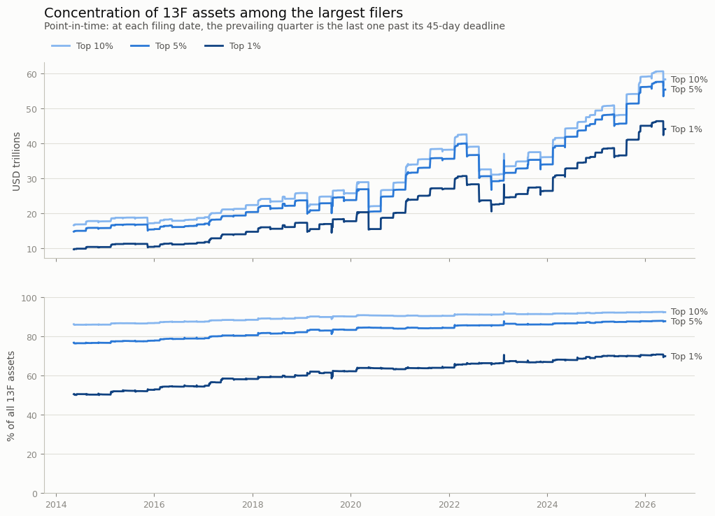

```python
lag = 45
analyzing_total(lag=lag)
```

Next, we get S&P 500 historical composition and prices data using the `get_spx_composition()` function:

```python
print('\n=== S&P 500 composition ===\n')
if not ((DATA_FINAL / 'spx_cusip.parquet').exists() and (DATA_FINAL / 'spx_close.parquet').exists()):
    cusip, close, index = get_spx_composition()
    cusip.to_parquet(DATA_FINAL / 'spx_cusip.parquet')
    close.to_parquet(DATA_FINAL / 'spx_close.parquet')
    index.to_parquet(DATA_FINAL / 'spx_index.parquet')
else:
    print('S&P 500 composition and prices already on disk, skipping')

    # The benchmark is one ticker, so a missing one is filled on its own rather than by redoing the 780 above
    if not (DATA_FINAL / 'spx_index.parquet').exists():
        get_spx_index(pd.read_parquet(DATA_FINAL / 'spx_cusip.parquet').index).to_parquet(DATA_FINAL / 'spx_index.parquet')
```

```
=== S&P 500 composition ===

S&P 500 composition and prices already on disk, skipping
```

```
Price coverage of index members, by year:
    2014    73.1%
    2015    74.8%
    2016    78.0%
    2017    80.7%
    2018    82.2%
    2019    84.5%
    2020    87.6%
    2021    89.5%
    2022    92.1%
    2023    94.6%
    2024    96.1%
    2025    97.3%
    2026    98.8%

  176 of 779 tickers ever in the index have no price at all (23%)
  examples: AABA, ABC, ABMD, ADS, ADT, AET, AGN, ALTR, ALXN, ANDV, ANSS, ANTM

  members per day (median): 504
  with a cusip : 99.0% on average | 95.2% at worst
  with a price : 85.6% on average | 70.0% in 2014 | 98.3% in 2026
```

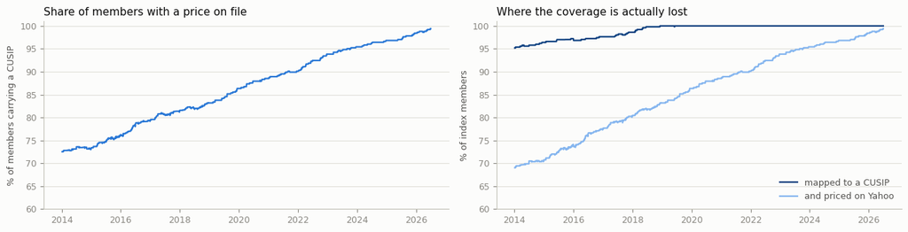

```python
import pandas as pd
import matplotlib.pyplot as plt

cmap  = pd.read_parquet(DATA_FINAL / 'spx_cusip.parquet')
close = pd.read_parquet(DATA_FINAL / 'spx_close.parquet')

# Holidays carry membership but no quote at all, and would read as a total loss of coverage
trading = close.notna().any(axis=1)

# Yahoo drops a ticker's history once the company stops existing, so what is missing here is not random:
# it is whoever was acquired, merged or went bankrupt
member = cmap.notna()
priced = member & close.notna()
cov    = (priced.sum(axis=1) / member.sum(axis=1)).loc[trading]
gone   = member.any() & ~close.notna().any()

print('Price coverage of index members, by year:')
for y, c in (cov.resample('YE').mean() * 100).items(): print(f'    {y.year}   {c:>5.1f}%')

print(f'\n  {int(gone.sum())} of {int(member.any().sum())} tickers ever in the index have no price at all ({gone.mean()*100:.0f}%)')
print(f'  examples: {", ".join(gone.loc[gone].index[:12])}')

# spx_cusip is already masked by the mapping, so index membership on its own has to be rebuilt to tell the two
# failures apart: a member we could not map to a cusip, and a member we could not price
url = ("https://raw.githubusercontent.com/fja05680/sp500/master/S%26P%20500%20Historical%20Components%20%26%20Changes%20(Updated).csv")

snp = pd.read_csv(url, parse_dates=['date'])
snp['tickers'] = snp['tickers'].str.split(',')
snp = snp.explode('tickers').rename(columns={'date':'Date','tickers':'Ticker'})
snp['Ticker'] = snp['Ticker'].str.strip().str.replace('.','',regex=False)
snp = snp.loc[snp['Date'] >= START_REF].reset_index(drop=True)
snp = pd.crosstab(snp['Date'], snp['Ticker']).clip(upper=1).resample('B').ffill()
snp = snp.reindex(index=cmap.index, columns=cmap.columns).fillna(0).astype(bool)

n_member  = snp.sum(axis=1)
cov_cusip = ((snp & member).sum(axis=1) / n_member).loc[trading] * 100
cov_price = ((snp & priced).sum(axis=1) / n_member).loc[trading] * 100

print(f"\n  members per day (median): {n_member.loc[trading].median():.0f}")
print(f"  with a cusip : {cov_cusip.mean():.1f}% on average | {cov_cusip.min():.1f}% at worst")
print(f"  with a price : {cov_price.mean():.1f}% on average | {cov_price.iloc[:250].mean():.1f}% in 2014 | {cov_price.iloc[-250:].mean():.1f}% in 2026")

fig, ax = plt.subplots(1, 2, figsize=(13, 3.4), facecolor='#fcfcfb')

ax[0].plot(cov.index, cov * 100, lw=1.6, color='#2a78d6')
ax[0].set_title('Share of members with a price on file', loc='left', fontsize=11, color='#0b0b0b')
ax[0].set_ylabel('% of members carrying a CUSIP', fontsize=9, color='#52514e')

ax[1].plot(cov_cusip.index, cov_cusip, lw=1.6, color='#104281', label='mapped to a CUSIP')
ax[1].plot(cov_price.index, cov_price, lw=1.6, color='#86b6ef', label='and priced on Yahoo')
ax[1].set_title('Where the coverage is actually lost', loc='left', fontsize=11, color='#0b0b0b')
ax[1].set_ylabel('% of index members', fontsize=9, color='#52514e')
ax[1].legend(frameon=False, fontsize=9, labelcolor='#52514e', loc='lower right')

for a in ax:
    a.set_ylim(60, 101)
    a.set_facecolor('#fcfcfb')
    a.grid(axis='y', color='#e1e0d9', lw=0.8)
    a.set_axisbelow(True)
    a.tick_params(colors='#898781', labelsize=9)
    for s in ('top','right'): a.spines[s].set_visible(False)
    for s in ('bottom','left'): a.spines[s].set_color('#c3c2b7')

plt.tight_layout()

plt.savefig(DATA_FINAL / 'coverage.png', dpi=150, bbox_inches='tight', facecolor='#fcfcfb')
```

Next step is constructing the universe of filers. We won't consider all investment managers in the construction of the factors, because some small filers could bias the factors. The rule I will construct will always get around 5% of the filers. There are four possible rules:

1. AUM: get the 5% of the largest filters by equity AUM (within the data from 13F fillings).
2. Position size variance (both the top and the bottom): the variance of the number of positions held. This can be considered a proxy for turnover, but not turnover itself, because a filer with 50 stocks may change its total 50 stock composition and the position size variance is zero.
3. Highest number of effective positions: for each filer, we construct the Herfindahl–Hirschman Index of each position, denoting the concentration of the filer's holdings. If a filer has 300 positions but most of it is in one, this one position will have a large HHI. The number of effective positions is the inverse of the HHI (so $\text{eff}_n = \frac{1}{\sum_i w_i^2}$, where $w_i$ is the share of each stock $i$ in the wallet of a manager), so if all positions are evenly distributed it will equal the number of positions. If there's only one large position and many small ones, the number will be close to 1. It's used as a proxy for managers with many bets.

For items 2 and 3, we also do a pre-filtering of the universe of managers. The reason is that there may be small managers with very high variance, for instance, and this may bias the selection of small firms. So we only select the 20% largest firms by AUM and then the 25% (to yield in the end 5% in total) with the largest effective number of positions or size variance (or lowest variance).

In this step, again, we need to look out for look-ahead bias. These ranking are only made using information available up to a given date, so if a manager add NEW HOLDINGS which for instance include it among the top 5% in AUM after the 45 days deadline, it'll only show up in the univere of CIKs after the amendment is sent.

```python
print('\n=== Filer universes ===')

RULES  = ['aum', 'cv_high', 'cv_low', 'conc']
pool   = 0.2
target = 0.05
top    = 10

for rule in RULES:
    print(f"\n-- {rule} --\n")
    if not (DATA_FINAL / f'13f_holdings_universe_{rule}.parquet').exists():
        create_final_dataset(rule=rule, pool=pool, target=target, top=top, lag=lag)
    else:
        print(f"Holdings for '{rule}' already on disk, skipping")
```

```
=== Filer universes ===

-- aum --

Holdings for 'aum' already on disk, skipping

-- cv_high --

Holdings for 'cv_high' already on disk, skipping

-- cv_low --

Holdings for 'cv_low' already on disk, skipping

-- conc --

Holdings for 'conc' already on disk, skipping
```

## Factor Creation

Now we can start to create the factors. Here's a detailed description. Every factor is evaluated on a **decision date** $d$, which is any day a filing lands or a filing deadline passes. The **prevailing quarter** $q(d)$ is the most recent quarter whose 45-day deadline has passed, $q + 45\text{d} \le d$, and $q^-$ is the quarter before it. The snapshot read on $d$ is the latest vintage of each $(\text{filer}, \text{quarter})$ pair filed up to $d$, restricted to the filers $F_d$ the selection rule picks on that date. Nothing filed after $d$ enters (to ensure we have PIT discipline), and the filer list is the one the rule would have produced on $d$, not the one it produces today.

Write $n_{i,c,q}$ for the share count of stock $c$ that filer $i$ reports for quarter $q$, $v_{i,c,q}$ for the value, and $w_{i,c,q} = v_{i,c,q} / \sum_k v_{i,k,q}$ for the weight the position takes inside that filer's **whole** book (not only S&P 500, which will be the universe allowed to investment for my backtesting strategy). Factors are computed on the whole book and only the output is cut to the S&P500 index members of the day.

### Net buying

Let $B = \{i \in F_d : i \text{ reported both } q \text{ and } q^-\}$ (i.e. the set of filers who reported in two subsequent periods).

$$\text{netbuy}_c = \frac{\sum_{i \in B} n_{i,c,q} - \sum_{i \in B} n_{i,c,q^-}}{\sum_{i \in B} n_{i,c,q} + \sum_{i \in B} n_{i,c,q^-}}$$

Share count rather than value, since value also carries the price move of the quarter, which is not a decision of the manager. The scaling bounds the factor in $[-1, 1]$, where $+1$ is a position the group only opened and $-1$ one it fully left, so entries and exits stay in the sample. Measures if filers are buying or selling the stock.

### Breadth change

$$\Delta\text{breadth}_c = \frac{\left|\{i \in B : n_{i,c,q} > 0\}\right| - \left|\{i \in B : n_{i,c,q^-} > 0\}\right|}{|B|}$$

Every filer counts once, whatever its size, which is what separates this from net buying: a name that forty small managers entered and one large manager left moves the two in opposite directions. The scaling by $|B|$ keeps it comparable over time, as the universe grows from roughly 350 to 870 filers. Measures if the stock is gaining or losing holders, regardless of how large each holder is.

### Conviction

With $H_c = \{i \in F_d : w_{i,c} > 0\}$ the filers actually holding $c$,

$$\text{conv}_c = \frac{1}{|H_c|} \sum_{i \in H_c} w_{i,c}$$

A level rather than a change, so it reads the prevailing quarter alone. It separates a real bet from a leftover: at equal number of holders, a security taking 4% of the books that own it is not the same as one taking 0.05%. Measures how large a bet the stock is inside the books of the managers who own it.

### Centrality

The prevailing quarter is pivoted into a matrix $B \in \mathbb{R}^{|F| \times |C|}$ with $B_{ic} = w_{i,c}$, keeping S&P 500 stocks on the columns and, on the rows, filers holding at least 10 stock positions. Columns are then centred around the mean of the position size for that stock among filers,

$$\tilde{B}_{ic} = B_{ic} - \frac{1}{|F|}\sum_{j} B_{jc}$$

so a cell says how far a filer sits from the average filer on that security rather than how much it holds. Without centring the leading component converges to the average portfolio, which is roughly the market, and the factor becomes a market cap proxy. Taking the leading singular triplet $\tilde{B} \approx s_1 u_1 v_1^{\top}$, the factor is

$$\text{centrality}_c = \left| v_{1,c} \right|$$

$v_1$ is equivalently the leading eigenvector of the co-deviation matrix $\tilde{B}^{\top}\tilde{B}$, which is the eigenvector centrality of the network whose edges are pairs of securities that managers deviate on together. On the other hand $u_1$ is the manager side of the same axis: one number per filer, saying how strongly its book follows the dominant pattern and on which of its two sides the manager sits.

I take the absolute value of $v$ because $v_1$ and $-v_1$ describe the same axis, that is, both solutions are feasible for the SVD decomposition (just invert the sign of $u$) and in some points in time, the resulting vector changes signs, meaning if we just used the raw value of this eigenvector, between two periods the factor value could invert completely. Using the absolute value solves the ordering problem, but the intuition is not exactly the same as looking at (a correctly ordered) $v$ vector.

Measures how much managers disagree with one another on how large a position to take in the stock.

I've created a unified pipeline for estimating the factors (except for the centrality measure, which does not support being part of the framework). Each factor requires only `snap` (a snapshot of the holdings at a given vintage date, which remember, can change with the amendments) and `layers` (the two consecutive quarters used to calculate the factor). Hence, `build_factors` just need parsed the `df` (the dataframe in final considering the universe of managers under consideration at each vintage, according to each rule) and the desired factor functions to construct and save the factors.

Centrality on the other hand, has its own function which is not compatible with the pipeline, because it needs the $B$ matrix constructed. However, it yields an object in the same format as the other factors, to make it easy to flow in the rest of the pipeline.

```python
from factors import *

depth = 2

print('\n=== Factors ===')
spx = pd.read_parquet(DATA_FINAL / 'spx_cusip.parquet')

RULES = ['aum', 'cv_high', 'cv_low', 'conc']

for rule in RULES:
    print(f"\n-- {rule} --\n")

    cen_paths = {'centrality'       : DATA_FACTORS / f'centrality_{rule}.parquet',
                'centrality_filers': DATA_FACTORS / f'centrality_filers_{rule}.parquet',
                'centrality_diag'  : DATA_FACTORS / f'centrality_diag_{rule}.parquet'}

    need_fac = not all((DATA_FACTORS / f'{name}_{rule}.parquet').exists() for name in FACTORS)
    need_cen = not all(p.exists() for p in cen_paths.values())

    if not (need_fac or need_cen):
        print(f"Factors for '{rule}' already on disk, skipping")
        continue

    df   = pd.read_parquet(DATA_FINAL / f'13f_holdings_universe_{rule}.parquet')
    univ = pd.read_parquet(DATA_INT / f'13f_cik_universe_{rule}.parquet')

    # The other factors can be created all from build_factors
    if need_fac:
        fac = build_factors(df, FACTORS, univ, spx, depth=depth, lag=lag)
        for name in FACTORS:
            fac[['cusip','date','ref_date', name]].to_parquet(DATA_FACTORS / f'{name}_{rule}.parquet', index=False)

    # Centrality walks on its own, and its filer side and diagnostics are written with it: they come out of the
    # same decomposition and rerunning a 2,300-date walk just to read them back would be the expensive way
    if need_cen:
        cen, hold, diag = build_centrality(df, univ, spx, lag=lag)
        cen.to_parquet(cen_paths['centrality'], index=False)
        hold.to_parquet(cen_paths['centrality_filers'], index=False)
        diag.reset_index().to_parquet(cen_paths['centrality_diag'], index=False)
```

```
=== Factors ===

-- aum --

Factors for 'aum' already on disk, skipping

-- cv_high --

Factors for 'cv_high' already on disk, skipping

-- cv_low --

Factors for 'cv_low' already on disk, skipping

-- conc --

Factors for 'conc' already on disk, skipping
```

We want to test how correlated our main factor, Centrality, is to the other three factors, which we use mainly as benchmark. If they are perfectly correlated, we might be skeptic of whether this new Centrality measure carries any additional advantage over others. In fact, we see that correlation is high (~0.7) with Conviction, being zero with other factors. It makes sense, as the measure used to center the S&P holdings is very closely related to the Conviction metric. We'll show below, at the backtesting part, however, that in terms of return, our strategy build with Centrality, has indeed an advantage over other measures.

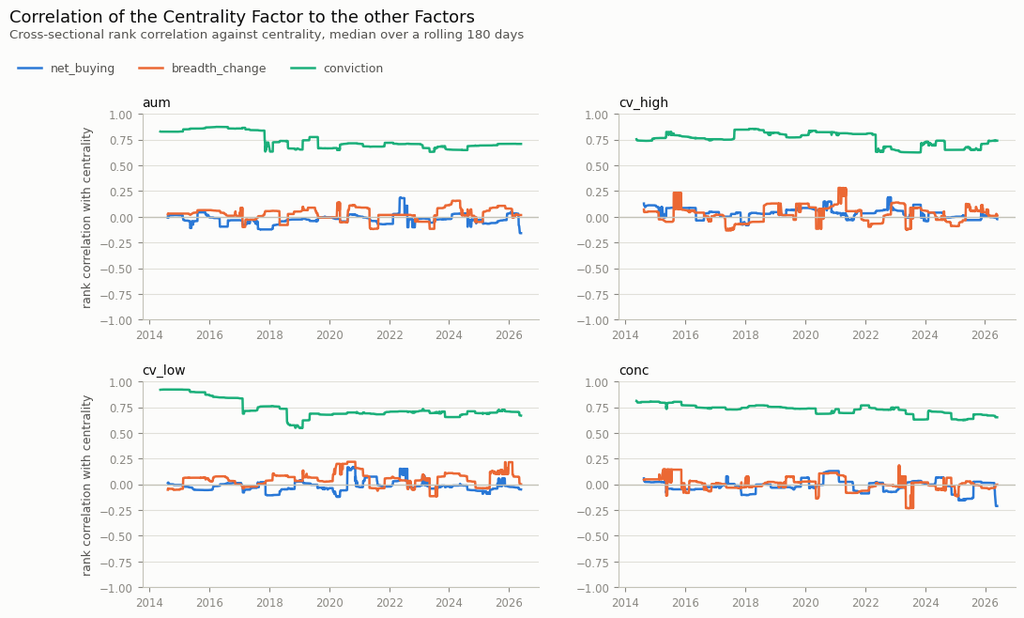

```python
RULES  = ['aum', 'cv_high', 'cv_low', 'conc']
OTHERS = ['net_buying', 'breadth_change', 'conviction']

INK    = {'primary':'#0b0b0b', 'secondary':'#52514e', 'muted':'#898781', 'grid':'#e1e0d9', 'axis':'#c3c2b7'}
COLOUR = {'net_buying':'#2a78d6', 'breadth_change':'#eb6834', 'conviction':'#1baf7a', 'centrality':'#4a3aa7'}
MARKER = {'net_buying':'o', 'breadth_change':'s', 'conviction':'^', 'centrality':'D'}

def rolling_corr(rule, window='180D'):
    """Cross-sectional rank correlation of centrality against each other factor, smoothed over time."""

    d = pd.read_parquet(DATA_FACTORS / f'centrality_{rule}.parquet')[['cusip','date','centrality']]
    for n in OTHERS:
        d = d.merge(pd.read_parquet(DATA_FACTORS / f'{n}_{rule}.parquet')[['cusip','date',n]], on=['cusip','date'])

    # Ranked inside each date once, so a plain correlation on the ranks is the Spearman of that cross-section,
    # without paying for one spearmanr call per date and per factor
    cols = ['centrality'] + OTHERS
    r    = d.groupby('date')[cols].rank()
    r['date'] = d['date']

    out = r.groupby('date').apply(lambda g: pd.Series({n: np.corrcoef(g['centrality'], g[n])[0, 1] for n in OTHERS}),
                                  include_groups=False)

    # The median over a rolling window, rather than the mean, because the roll dates move the whole cross-section
    # at once and would otherwise drag the line for months
    return out.rolling(window).median()

fig, ax = plt.subplots(2, 2, figsize=(12, 7), facecolor='#fcfcfb')

for a, rule in zip(ax.flat, RULES):
    c = rolling_corr(rule)

    for n in OTHERS:
        a.plot(c.index, c[n], lw=1.8, color=COLOUR[n], label=n, zorder=3)

    a.axhline(0, lw=1, color=INK['axis'], zorder=4)
    a.set_ylim(-1, 1)
    a.set_title(rule, loc='left', fontsize=10, color=INK['primary'])
    a.set_facecolor('#fcfcfb')
    a.grid(axis='y', color=INK['grid'], lw=0.8)
    a.set_axisbelow(True)
    a.tick_params(colors=INK['muted'], labelsize=8.5)
    for s in ('top','right'): a.spines[s].set_visible(False)
    for s in ('bottom','left'): a.spines[s].set_color(INK['axis'])

for a in ax[:, 0]: a.set_ylabel('rank correlation with centrality', fontsize=9, color=INK['secondary'])

fig.suptitle('Correlation of the Centrality Factor to the other Factors', x=0.007, y=0.99, ha='left',
             fontsize=13, color=INK['primary'])
fig.text(0.007, 0.945, 'Cross-sectional rank correlation against centrality, median over a rolling 180 days',
         ha='left', fontsize=9.5, color=INK['secondary'])
fig.legend(*ax[0, 0].get_legend_handles_labels(), frameon=False, fontsize=9, labelcolor=INK['secondary'],
           ncol=3, loc='upper left', bbox_to_anchor=(0.005, 0.925))
fig.subplots_adjust(top=0.83, hspace=0.3)

plt.savefig(DATA_FINAL / 'factor_correlation.png', dpi=150, bbox_inches='tight', facecolor='#fcfcfb')
```

## Backtesting and Comparing Factors

With the factors built and saved for each combination of manager universe (total of 16 combinations of factor), we can now run the backtesting. I create a unified framework for backtesting as well. Given that all factors yield a dataset in the same format, this framework is built in two steps. First, we build the strategy, showing the percentage of our portfolio held in each S&P500 stock. All we need to do is give the function `build_strategy` the name of the factor we're considering, the rule (pool of managers), the start date to allocate the strategy (in our case after the deadline of the second quarter available), the frequency of rebalancing (quarterly, monthly, or weekly), the side (whether we allow for long-short or long-only) and the cap on the $z$-score of each factor (to avoid having one stock with an outlier normalized factor dominating our portfolio). It returns the $w$ matrix showing for each business day, the share of the portfolio allocated in each stock.

It builds the allocation using the result from Lasse Heje Pedersen's 2015 book "Efficiently Inefficient" that a cross-section regression of returns on the factor yield an allocation strategy and weights. Take a rebalance date $d$. For the current quarter $T$ (defined as the previous quarter if its deadline has already passed), it regresses the stock return $r_{i}^{T}$ between the end date of $T$ with the end date of the previous quarter $T-1$ on the factor in $T$ as of date $d$, denoted $F_{i,d}^{T}$, that is, only using information available up to $d$:

$$ r_i^T = a + b F_{i,d}^{T} + e_i^T $$

Pedersen shows that the regression coefficient $b$ is the profit of a long-short security selection strategy realized between $T-1$ and $T$. Thus, the position in each security $i$ is given by at rebalance date $d$ is equal to:

$$ x_{d}^i = \frac{(F_{i,d} - \bar{F}_{d})}{\sum_j (F_{j,d} - \bar{F}_{d})^2} $$

The strategy goes long in stocks with signal better than the average and short on stocks with low signal. In the long only strategy, we cap the allocation only to positive values.

The function `run_backtest` effectively runs the backtest of the strategy. It uses as input the matrix $w$ from `build_strategy` to create a portfolio and estimates its daily returns based on the prices from Yahoo Finance, always starting to count the returns of the strategy at $d+1. The weights may float with price changes, but the complete reweighting is only done at the next rebalance date. It also has a cost and a risk-free parameters (fixed at 2%). The cost parameter denotes the transaction costs of portfolio rebalancing. It is charged on the full notional traded (buys + sells).

We want to estimate all possible strategies in this framework. Remember that we don't know exactly under which pool of managers each factor strategy might work better, so we test all possible combinations of:

1. Pool of managers (4 combinations)
2. Positioning factors (4 combinations)
3. Frequencies (3 combinations)
4. Long-only or long-short (2 combinations)
5. Trading costs (0, 5, 10, or 20 bps, 4 combinations)

Yielding 384 combinations. These combinations are then saved in an Excel file called backtest_grid.xlsx, with statistics of these strategies.

```python
from trading_strategy import *

alloc_start = '2015-01-01'
freqs       = ('W','ME','QE')
costs       = (0,5,10,20)
NAMES       = list(FACTORS) + ['centrality']
rf          = 0.02

ret  = daily_returns()
n    = len(RULES) * len(NAMES) * len(freqs) * 2
rows = []

# The index is the price one and the security prices carry no dividends either, so the two sides of every
# comparison below are measured on the same footing
bench = pd.read_parquet(DATA_FINAL / 'spx_index.parquet')['spx'].pct_change(fill_method=None)

for rule in RULES:
    for name in NAMES:
        for freq in freqs:
            for side in ['long_short','long_only']:
                w  = build_strategy(name, rule, start=alloc_start, freq=freq, side=side)
                bt = run_backtest(w, cost=0.0, rf=rf, ret=ret)

                # The traded notional is twice the reported one-way turnover, and it is what every cost level
                # is charged on, so each level is the gross series minus a known amount
                traded = bt['turnover'] * 2
                days   = len(bt)

                # Benchmark on the same period
                b     = bench.reindex(bt.index).fillna(0.0)
                bann  = float((1 + b).prod() ** (252 / days) - 1)
                bvol  = float(b.std() * np.sqrt(252))
                beta  = float(b.cov(bt['ret']) / b.var())

                for c in costs:
                    r   = bt['ret'] - c / 1e4 * traded
                    nav = (1 + r).cumprod()
                    ann = float(nav.iloc[-1] ** (252 / days) - 1)
                    vol = float(r.std() * np.sqrt(252))
                    dd  = float((nav / nav.cummax() - 1).min())
                    ex  = r - b

                    rows.append({'rule'          : rule,
                                'factor'         : name,
                                'freq'           : freq,
                                'side'           : side,
                                'cost_bps'       : c,
                                'ann_return'     : ann,
                                'ann_vol'        : vol,
                                'sharpe'         : (ann - rf) / vol,
                                't_stat'         : float(r.mean() / r.std() * np.sqrt(days)),
                                'max_drawdown'   : dd,
                                'calmar'         : ann / abs(dd),
                                'final_nav'      : float(nav.iloc[-1]),
                                'hit_rate'       : float(r.gt(0).mean()),
                                'best_day'       : float(r.max()),
                                'worst_day'      : float(r.min()),
                                'skew'           : float(r.skew()),
                                'bench_return'   : bann,
                                'bench_vol'      : bvol,
                                'bench_sharpe'   : (bann - rf) / bvol,
                                'excess_return'  : ann - bann,
                                'beta'           : beta,
                                'alpha'          : float((r.mean() - beta * b.mean()) * 252),
                                'info_ratio'     : float(ex.mean() / ex.std() * np.sqrt(252)),
                                'turnover_yr'    : float(bt['turnover'].sum() / days * 252),
                                'cost_yr'        : float(c / 1e4 * traded.sum() / days * 252),
                                'n_rebalances'   : int(bt['turnover'].gt(0).sum()),
                                'names_median'   : int((w != 0).sum(axis=1).median()),
                                'gross_median'   : float(bt['gross'].iloc[1:].median()),
                                'net_median'     : float(bt['net'].iloc[1:].median()),
                                'start'          : bt.index.min().date(),
                                'end'            : bt.index.max().date()})

                print(f"    {len(rows)//len(costs)}/{n} done")

grid = pd.DataFrame(rows).sort_values('sharpe', ascending=False, ignore_index=True)
grid.to_excel(DATA_FINAL / 'backtest_grid.xlsx', index=False, sheet_name='backtest')
```

```
    1/96 done
    2/96 done
    3/96 done
    4/96 done
    5/96 done
    6/96 done
    7/96 done
    8/96 done
    9/96 done
    10/96 done
    11/96 done
    12/96 done
    13/96 done
    14/96 done
    15/96 done
    16/96 done
    17/96 done
    18/96 done
    19/96 done
    20/96 done
    21/96 done
    22/96 done
    23/96 done
    24/96 done
    25/96 done
    26/96 done
    27/96 done
    28/96 done
    29/96 done
    30/96 done
    31/96 done
    32/96 done
    33/96 done
    34/96 done
    35/96 done
    36/96 done
    37/96 done
    38/96 done
    39/96 done
    40/96 done
```

[output cut: 41 more lines]

```
    82/96 done
    83/96 done
    84/96 done
    85/96 done
    86/96 done
    87/96 done
    88/96 done
    89/96 done
    90/96 done
    91/96 done
    92/96 done
    93/96 done
    94/96 done
    95/96 done
    96/96 done
```

```python
# Creating the setup for the following analysis blocks
COST, START = 5, '2015-01-01'

grid  = pd.read_excel(DATA_FINAL / 'backtest_grid.xlsx')
ret   = daily_returns()
bench = pd.read_parquet(DATA_FINAL / 'spx_index.parquet')['spx'].pct_change(fill_method=None)
nm    = pd.read_parquet(DATA_INT / 'cusip_issuer.parquet').set_index('cusip')['nameofissuer']

# The single combination the rest of the write-up follows, picked under the cost assumption stated above
BEST = grid.loc[grid['side'].eq('long_only') & grid['cost_bps'].eq(COST)].nlargest(1, 'sharpe').iloc[0]
w    = build_strategy(BEST['factor'], BEST['rule'], start=START, freq=BEST['freq'], side='long_only')
bt   = run_backtest(w, cost=COST, ret=ret)

print(f"\nheadline strategy: {BEST['factor']} on {BEST['rule']}, {BEST['freq']}, long-only at {COST} bps")
```

```
headline strategy: centrality on cv_high, QE, long-only at 5 bps
```

Now we can start comparing strategies:

```python
COST = 5
COLS = ['factor','rule','freq','ann_return','ann_vol','sharpe','t_stat','alpha','beta',
        'max_drawdown','turnover_yr','final_nav']

def leaders(side, n=5):
    """The n best combinations of a side, with the index underneath on the same footing."""

    d = grid.loc[grid['side'].eq(side) & grid['cost_bps'].eq(COST)].copy()

    # A dollar neutral book funds itself, so its return is already an excess return and the risk free rate must
    # not be charged against it a second time. The long-only book does commit capital, so there it does
    if side == 'long_short': d['sharpe'] = d['ann_return'] / d['ann_vol']

    t = d.nlargest(n, 'sharpe')[COLS]

    b = d.iloc[0]
    t.loc['S&P 500'] = ['', '', '', b['bench_return'], b['bench_vol'], b['bench_sharpe'],
                        None, None, 1.0, None, None, None]

    for c in ['ann_return','ann_vol','alpha','max_drawdown','turnover_yr']: t[c] = t[c] * 100
    return t.round(2)

for side in ['long_only','long_short']:
    print(f"\n{'='*112}\n  Top 5 {side.replace('_','-')} by Sharpe, at {COST} bps\n{'='*112}")
    print(leaders(side).to_string())

# Whether a factor leads because of one lucky configuration or across all of them is the question a grid of 384
# has to answer before any single number inside it can be quoted
print(f"\n{'='*112}\n  Every configuration of each factor: 4 rules x 3 frequencies, at {COST} bps\n{'='*112}")

for side in ['long_only','long_short']:
    d = grid.loc[grid['side'].eq(side) & grid['cost_bps'].eq(COST)].copy()
    if side == 'long_short': d['sharpe'] = d['ann_return'] / d['ann_vol']

    t = d.groupby('factor').agg(median_sharpe=('sharpe','median'), worst=('sharpe','min'), best=('sharpe','max'),
                                median_t=('t_stat','median'),
                                beats_index=('sharpe', lambda s: int((s > d['bench_sharpe'].iloc[0]).sum())))
    print(f"\n  {side.replace('_','-')}:")
    print(t.sort_values('median_sharpe', ascending=False).round(3).to_string())
```

```
================================================================================================================
  Top 5 long-only by Sharpe, at 5 bps
================================================================================================================
             factor     rule freq  ann_return  ann_vol  sharpe  t_stat  alpha  beta  max_drawdown  turnover_yr  final_nav
1        centrality  cv_high   QE       18.13    21.95    0.73    2.96   3.67  1.14        -36.40       107.33       6.87
6        centrality   cv_low   QE       15.17    18.53    0.71    2.91   2.05  1.02        -32.87        68.54       5.13
8        centrality  cv_high   ME       17.38    21.77    0.71    2.89   2.93  1.14        -37.07       138.93       6.55
14       centrality      aum   QE       14.87    18.85    0.68    2.82   1.56  1.05        -33.85        71.20       4.96
17       centrality  cv_high    W       16.67    21.68    0.68    2.81   2.62  1.14        -37.34       209.50       6.16
S&P 500                                 12.74    17.21    0.62     NaN    NaN  1.00           NaN          NaN        NaN

================================================================================================================
  Top 5 long-short by Sharpe, at 5 bps
================================================================================================================
                 factor     rule freq  ann_return  ann_vol  sharpe  t_stat  alpha  beta  max_drawdown  turnover_yr  final_nav
204      breadth_change  cv_high   QE        0.96     3.57    0.27    0.97   1.20 -0.01        -11.03       307.75       1.12
194      breadth_change   cv_low   QE        0.90     4.87    0.19    0.71   1.74 -0.05        -18.13       290.14       1.11
236      breadth_change      aum   QE        0.55     4.32    0.13    0.50   1.60 -0.07        -17.50       303.88       1.07
270      breadth_change     conc   QE        0.48     3.82    0.13    0.49   1.23 -0.05        -14.62       306.51       1.06
196          conviction      aum   QE        0.55     5.73    0.10    0.43   1.75 -0.08        -21.10        44.88       1.07
S&P 500                                     12.77    17.21    0.63     NaN    NaN  1.00           NaN          NaN        NaN

================================================================================================================
  Every configuration of each factor: 4 rules x 3 frequencies, at 5 bps
================================================================================================================

  long-only:
                median_sharpe  worst   best  median_t  beats_index
factor
centrality              0.666  0.589  0.735     2.792            9
conviction              0.588  0.556  0.603     2.567            0
breadth_change          0.377  0.306  0.468     1.909            0
net_buying              0.310  0.186  0.409     1.693            0

  long-short:
                median_sharpe  worst   best  median_t  beats_index
factor
conviction              0.055  0.005  0.097     0.279            0
centrality             -0.073 -0.300  0.015    -0.141            0
breadth_change         -0.132 -0.420  0.270    -0.382            0
net_buying             -0.438 -0.834 -0.006    -1.454            0
```

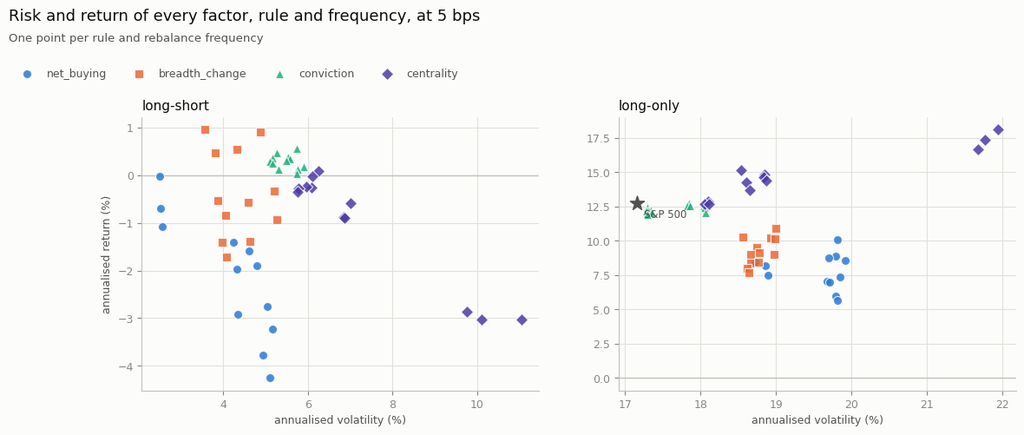

```python
d_all = grid.loc[grid['cost_bps'].eq(COST)]

fig, ax = plt.subplots(1, 2, figsize=(13, 5), facecolor='#fcfcfb')

for a, side in zip(ax, ['long_short', 'long_only']):
    d = d_all.loc[d_all['side'].eq(side)]

    for name in COLOUR:
        s = d.loc[d['factor'].eq(name)]
        if s.empty: continue
        a.scatter(s['ann_vol'] * 100, s['ann_return'] * 100, s=52, c=COLOUR[name], marker=MARKER[name],
                  alpha=0.85, linewidths=0.8, edgecolors='#fcfcfb', label=name, zorder=3)

    # The index belongs on the long only panel alone: the two carry the same market risk, so a point above it is
    # one that beat simply owning the market. Against a dollar neutral book it is not a comparable
    if side == 'long_only':
        bx, by = d['bench_vol'].median() * 100, d['bench_return'].median() * 100
        a.scatter([bx], [by], s=150, marker='*', c=INK['secondary'], zorder=5)
        a.annotate('S&P 500', (bx, by), xytext=(6, -12), textcoords='offset points',
                   fontsize=8.5, color=INK['secondary'])

    a.axhline(0, lw=1, color=INK['axis'], zorder=1)
    a.set_title(f"{side.replace('_', '-')}", loc='left', fontsize=11, color=INK['primary'])
    a.set_xlabel('annualised volatility (%)', fontsize=9, color=INK['secondary'])
    a.set_facecolor('#fcfcfb')
    a.grid(color=INK['grid'], lw=0.8)
    a.set_axisbelow(True)
    a.tick_params(colors=INK['muted'], labelsize=9)
    for sp in ('top','right'): a.spines[sp].set_visible(False)
    for sp in ('bottom','left'): a.spines[sp].set_color(INK['axis'])

ax[0].set_ylabel('annualised return (%)', fontsize=9, color=INK['secondary'])

# Title, subtitle and legend each get a band of their own above the axes, so none of the three lands on another
fig.suptitle(f'Risk and return of every factor, rule and frequency, at {COST} bps', x=0.007, y=0.99,
             ha='left', fontsize=13, color=INK['primary'])
fig.text(0.007, 0.915, 'One point per rule and rebalance frequency',
         ha='left', fontsize=9.5, color=INK['secondary'])

fig.legend(*ax[0].get_legend_handles_labels(), frameon=False, fontsize=9, labelcolor=INK['secondary'],
           ncol=4, loc='upper left', bbox_to_anchor=(0.005, 0.875))
fig.subplots_adjust(top=0.74)

plt.savefig(DATA_FINAL / 'risk_return.png', dpi=150, bbox_inches='tight', facecolor='#fcfcfb')
```

However, it does not seem to be a good factor for the long-short strategies, with other strategies yielding higher returns at lower risk. Particularly, the Breadth Change factor is superior, with most Centrality strategies having negative returns.

Among all long-only strategies, the best Sharpe ratio comes from centrality, using the universe of firms with high variance in the number of shares held (proxy for high turnover) and quarterly rebalancing, a Sharpe ratio of 0.73 with return equal 18.13% and 3.7% of α, superior to the S&P 500 Sharpe of 0.62. Its market β is 1.14.

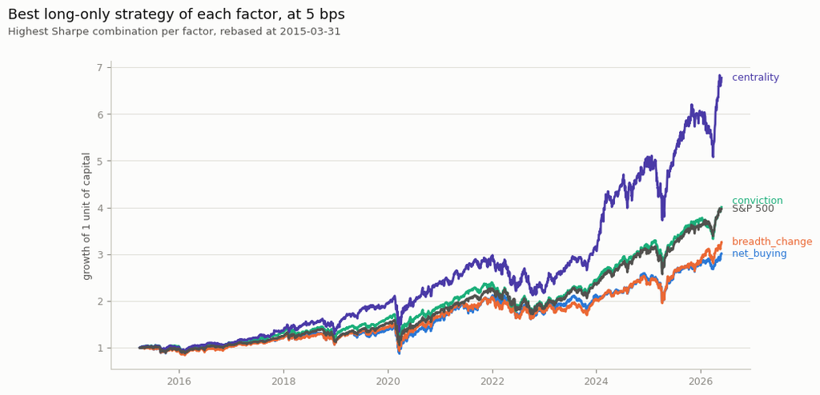

```python
# One line per factor: the best long-only combination each of them reaches, against the index
best = grid.loc[grid['side'].eq('long_only') & grid['cost_bps'].eq(COST)].sort_values('sharpe').groupby('factor').tail(1)

runs = {}
for r in best.itertuples():
    wf = build_strategy(r.factor, r.rule, start=START, freq=r.freq, side='long_only')
    runs[r.factor] = run_backtest(wf, cost=COST, ret=ret)['ret']


# Frequencies do not all start on the same day, so everything is cut to the latest start and rebased there:
# otherwise a line that began earlier would carry a head start that has nothing to do with the factor
first = max(s.index.min() for s in runs.values())
last  = min(s.index.max() for s in runs.values())

runs['S&P 500'] = bench
navs = {k: (1 + s.loc[first:last].fillna(0)).cumprod() for k, s in runs.items()}

fig, ax = plt.subplots(figsize=(11, 5.2), facecolor='#fcfcfb')

for name, nav in navs.items():
    ax.plot(nav.index, nav, lw=2, color=COLOUR.get(name, INK['secondary']), label=name, zorder=3)

# Direct labels at the right edge, nudged apart where two lines end close together
ends = sorted((float(nav.iloc[-1]), name) for name, nav in navs.items())
gap  = 0.045 * (max(e[0] for e in ends) - min(e[0] for e in ends))
for i, (y, name) in enumerate(ends):
    if i and y - ends[i-1][0] < gap: y = ends[i-1][0] + gap
    ends[i] = (y, name)
    ax.annotate(f'  {name}', (nav.index[-1], y), xytext=(4, 0), textcoords='offset points',
                va='center', fontsize=9, color=COLOUR.get(name, INK['secondary']))

ax.set_ylabel('growth of 1 unit of capital', fontsize=9, color=INK['secondary'])
ax.set_facecolor('#fcfcfb')
ax.grid(axis='y', color=INK['grid'], lw=0.8)
ax.set_axisbelow(True)
ax.tick_params(colors=INK['muted'], labelsize=9)
for s in ('top','right'): ax.spines[s].set_visible(False)
for s in ('bottom','left'): ax.spines[s].set_color(INK['axis'])

fig.suptitle(f'Best long-only strategy of each factor, at {COST} bps', x=0.007, y=0.99, ha='left',
             fontsize=13, color=INK['primary'])
fig.text(0.007, 0.925, f"Highest Sharpe combination per factor, rebased at {first.date()}",
         ha='left', fontsize=9.5, color=INK['secondary'])
fig.subplots_adjust(top=0.86, right=0.86)

plt.savefig(DATA_FINAL / 'cumulative_returns.png', dpi=150, bbox_inches='tight', facecolor='#fcfcfb')
```

```python
con = contributions(w, cost=COST, ret=ret, freq='YE')

print(f"\n{BEST['factor']} on {BEST['rule']}, {BEST['freq']} | contribution in units of initial capital\n")
for p, row in con.iterrows():
    top = row.nlargest(3)
    print(f"  {p.year}   " + ' | '.join(f'{str(nm.get(c, c))[:22]} {v:+.2f}' for c, v in top.items()))
```

```
Contributions | 263 securities | 12 periods | they add up to +5.866 of the initial capital

centrality on cv_high, QE | contribution in units of initial capital

  2015   MICROSOFT CORP +0.01 | AMAZON COM INC +0.01 | CONAGRA BRANDS INC +0.00
  2016   HCA HEALTHCARE INC COM +0.01 | WILLIAMS COS INC +0.01 | MICROSOFT CORP +0.01
  2017   STRYKER CORPORATION +0.09 | VISA INC +0.03 | AMAZON COM INC +0.02
  2018   MICROSOFT CORP +0.02 | VISA INC +0.01 | AMAZON COM INC +0.01
  2019   STRYKER CORPORATION +0.27 | MICROSOFT CORP +0.08 | APPLE INC +0.04
  2020   APPLE INC +0.11 | STRYKER CORPORATION +0.11 | AMAZON COM INC +0.08
  2021   MICROSOFT CORP +0.12 | APPLE INC +0.10 | STRYKER CORPORATION +0.07
  2022   METTLER TOLEDO INTERNA +0.01 | ROYAL CARIBBEAN GROUP +0.00 | UNITEDHEALTH GROUP INC +0.00
  2023   MICROSOFT CORP +0.13 | AMAZON COM INC +0.12 | TESLA INC +0.10
  2024   NVIDIA ORD +0.92 | META PLATFORMS INC +0.21 | AMAZON COM INC +0.15
  2025   NVIDIA ORD +0.32 | ALPHABET INC +0.17 | APPLE INC +0.12
  2026   ADVANCED MICRO DEVICES +0.18 | NVIDIA ORD +0.15 | MICRON TECHNOLOGY INC +0.14
```

## Evaluating the Factor's Signal and Possible Look-ahead Bias

What we presented above measured how well a strategy behave, i.e., a partigular weighting of a given factor. Since a strategy may work for reasons not related to how the factor orders the stocks, in this subsection we would like to test the factor on its own. On each quarterly decision date, the S&P stocks are sorted into ten decilers by the factor. We want to know if the higher/lower deciles have different returns from the rest. The chart below shows that there does not seem to be any clear sign in terms of returns from the Centrality factor itself. There does not seem to be a clear difference between deciles of the factor, and the difference between the 1st and the 10th is not significant (t-stat equal to 0.67). Visually speaking, the only factor which seems to carry some monotonicity is breadth change, even though its 1st to 10th decile difference is not significant either. The main gain, therefore, seems to come from the unbalanced betting on the factor, betting way deeper on stocks in the very top of the 10th decile.

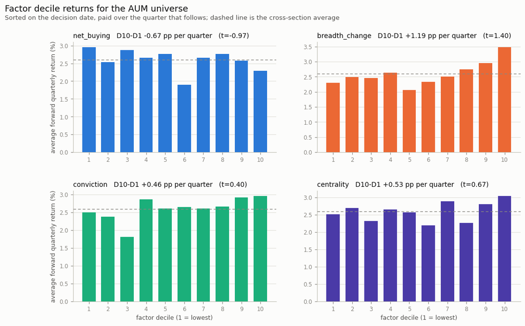

```python
# Sorting is done on the aum universe alone: the question here is about the factor, and repeating it across
# four universes would answer a different one
RULE = 'aum'

def deciles(factor, rule=RULE, freq='QE'):
    """Forward return of each decile of the factor, sorted on the date the decile is formed."""

    fac = pd.read_parquet(DATA_FACTORS / f'{factor}_{rule}.parquet').dropna(subset=[factor])

    d = pd.DatetimeIndex(np.sort(fac['date'].unique()))
    d = d[d >= pd.Timestamp(START)]
    rebal = pd.DatetimeIndex(d.to_series().resample(freq).last().dropna())

    out = []
    for a, b in zip(rebal[:-1], rebal[1:]):
        day = fac.loc[fac['date'].eq(a)].set_index('cusip')[factor]
        if len(day) < 50: continue

        # Sorted on the date the position would be taken, and paid over the window that follows it
        fwd = (1 + ret.loc[a:b].iloc[1:]).prod() - 1
        t   = pd.DataFrame({'f': day, 'fwd': fwd}).dropna()

        t['decile'] = pd.qcut(t['f'].rank(method='first'), 10, labels=range(1, 11))
        out.append(t.groupby('decile', observed=True)['fwd'].mean().rename(a))

    return pd.DataFrame(out)

fig, ax = plt.subplots(2, 2, figsize=(12, 7), facecolor='#fcfcfb')

for a, factor in zip(ax.flat, COLOUR):
    d = deciles(factor)
    m = d.mean() * 100

    a.bar(range(1, 11), m, color=COLOUR[factor], zorder=3, width=0.7)
    a.axhline(float(m.mean()), lw=1, ls=(0, (4, 3)), color=INK['muted'], zorder=4)

    # The spread between the ends is the number the whole chart exists to produce
    sp = d[10] - d[1]
    a.set_title(f"{factor}   D10-D1 {sp.mean()*100:+.2f} pp per quarter   (t={sp.mean()/sp.std()*np.sqrt(len(sp)):.2f})",
                loc='left', fontsize=10, color=INK['primary'])

    a.set_xticks(range(1, 11))
    a.set_facecolor('#fcfcfb')
    a.grid(axis='y', color=INK['grid'], lw=0.8)
    a.set_axisbelow(True)
    a.tick_params(colors=INK['muted'], labelsize=8.5)
    for s in ('top','right'): a.spines[s].set_visible(False)
    for s in ('bottom','left'): a.spines[s].set_color(INK['axis'])

for a in ax[1]: a.set_xlabel('factor decile (1 = lowest)', fontsize=9, color=INK['secondary'])
for a in ax[:, 0]: a.set_ylabel('average forward quarterly return (%)', fontsize=9, color=INK['secondary'])

fig.suptitle(f'Factor decile returns for the {RULE.upper()} universe', x=0.007, y=0.99, ha='left',
             fontsize=13, color=INK['primary'])
fig.text(0.007, 0.945, 'Sorted on the decision date, paid over the quarter that follows; dashed line is the cross-section average',
         ha='left', fontsize=9.5, color=INK['secondary'])
fig.subplots_adjust(top=0.88, hspace=0.35)

plt.savefig(DATA_FINAL / 'factor_deciles.png', dpi=150, bbox_inches='tight', facecolor='#fcfcfb')
```

We also want to test how sensitive to look-ahead bias our strategies might be. Evidence of look-ahead would be to always select the winners, instead of selecing the stocks which hold large factor values. This does not seem to be the case. We took two examples below (the quarter where Stryker brought the highest return to the portfolio and one of the best quarters) to show that we're not picking the best returns, but indeed the companies with the highest factor value. Moreover, there are several partitions of the trading days where our strategy performs way worse than the market (including 10% drawdown relative to the S&P in early 2025), also evidence against any PIT indiscipline.

```python
RULE, FREQ, FACTOR = BEST['rule'], BEST['freq'], BEST['factor']

fac     = pd.read_parquet(DATA_FACTORS / f'{FACTOR}_{RULE}.parquet')
rebal   = w.index[w.diff().abs().sum(axis=1).gt(0)].union(w.index[:1])
filings = pd.read_parquet(DATA_FINAL / f'13f_holdings_universe_{RULE}.parquet',
                          columns=['cik','ref_date','vintage_date'])

def walk(d, cusip=None, top=5):
    """Everything the strategy knew on the decision date, and everything that happened after it."""

    d    = rebal[rebal <= pd.Timestamp(d)].max()
    nxt  = rebal[rebal > d].min()
    day  = fac.loc[fac['date'].eq(d)].set_index('cusip')
    q    = day['ref_date'].iloc[0]
    fwd  = (1 + ret.loc[d:nxt].iloc[1:]).prod() - 1
    seen = filings.loc[filings['ref_date'].eq(q)]

    print(f"\n{d.date()} reads {q.date()}, due {(q + pd.Timedelta(days=45)).date()}, "
          f"{seen.loc[seen['vintage_date'].le(d),'cik'].nunique()} of {seen['cik'].nunique()} filings in hand"
          f"  |  window ends {nxt.date()}")

    t = pd.DataFrame({'fwd': fwd, 'pct': day[FACTOR].rank(pct=True), 'w': w.loc[d]}).dropna()

    if cusip:
        r = t.loc[cusip]
        print(f"  {nm.get(cusip)}: factor pct {r['pct']*100:.1f} | weight {r['w']*100:.2f}% | return {r['fwd']*100:+.1f}%")

    for lab, col in [('best over the window', 'fwd'), ('largest positions', 'w')]:
        print(f"\n  {lab:<30}{'return':>8}{'factor pct':>12}{'weight':>9}")
        for c, r in t.nlargest(top, col).iterrows():
            print(f"    {str(nm.get(c, c))[:26]:<28}{r['fwd']*100:>8.1f}%{r['pct']*100:>11.1f}{r['w']*100:>8.2f}%")

    miss = t.loc[t['w'].eq(0)].nlargest(top, 'fwd')['fwd'].mean()
    print(f"\n  book {float((t['w'] * t['fwd']).sum())*100:+.1f}%  |  best {top} names not held {miss*100:+.1f}%")

walk('2019-07-01', cusip='863667101')
walk('2025-03-31')
```

```
2019-06-27 reads 2019-03-31, due 2019-05-15, 966 of 982 filings in hand  |  window ends 2019-09-27
  STRYKER CORPORATION: factor pct 100.0 | weight 55.00% | return +5.5%

  best over the window            return  factor pct   weight
    WESTERN DIGITAL CORP            35.8%       48.7    0.00%
    KLA CORP                        34.6%       42.9    0.00%
    HUNT J B TRANS SVCS INC         23.8%       19.8    0.00%
    Lam Research Corp               23.6%       59.9    0.00%
    TARGET CORP                     23.6%       77.8    0.00%

  largest positions               return  factor pct   weight
    STRYKER CORPORATION              5.5%      100.0   55.00%
    MICROSOFT CORP                   2.7%       99.8    7.18%
    AMAZON COM INC                  -9.4%       99.6    4.96%
    APPLE INC                        9.6%       99.4    3.00%
    CHARTER COMMUNICATIONS INC       3.8%       99.2    2.61%

  book +4.1%  |  best 5 names not held +28.3%

2025-03-17 reads 2024-12-31, due 2025-02-14, 976 of 982 filings in hand  |  window ends 2025-06-23

  best over the window            return  factor pct   weight
    PALANTIR TECHNOLOGIES INC       60.2%       88.7    0.00%
    NRG ENERGY INC                  58.2%       32.8    0.00%
    DOLLAR TREE INC                 52.8%        9.5    0.00%
    JABIL INC                       50.6%        2.4    0.00%
    GE VERNOVA INC                  50.6%       93.6    0.10%

  largest positions               return  factor pct   weight
    NVIDIA ORD                      20.6%      100.0   19.28%
    MICROSOFT CORP                  25.0%       99.8   13.06%
    AMAZON COM INC                   6.5%       99.6   12.69%
    APPLE INC                       -5.8%       99.4   11.96%
    META PLATFORMS INC              15.5%       99.2   11.30%

  book +13.4%  |  best 5 names not held +54.2%
```

```
Strategy vs S&P 500, by quarter | 46 periods
  strategy ahead in       30 of 46  (65%)
  average excess          +1.41 pp | median +1.07 pp
  best / worst period     +22.9 pp / -9.5 pp

  when the S&P rose  (35 periods): ahead in 24  ( 69%) | average +1.89 pp
  when the S&P fell  (11 periods): ahead in  6  ( 55%) | average -0.12 pp
```

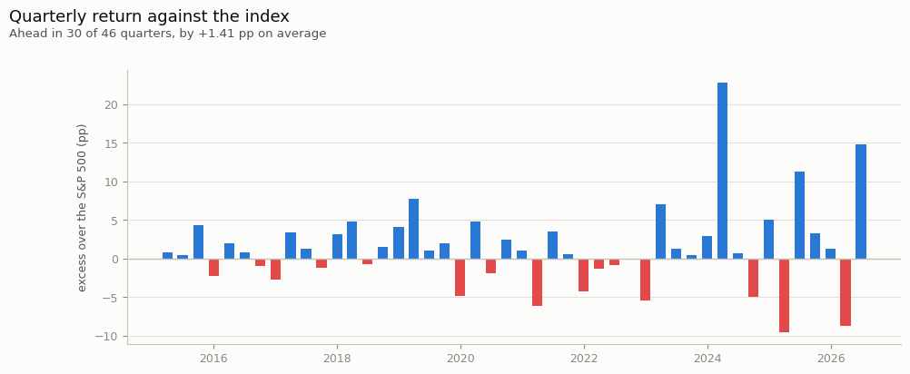

```python
PERIOD   = 'QE'
UP, DOWN = '#2a78d6', '#e34948'

s = bt['ret']
b = bench.reindex(s.index).fillna(0.0)

# Compounded inside each period, so the comparison is between what the two actually returned over it
S = (1 + s).resample(PERIOD).prod() - 1
B = (1 + b).resample(PERIOD).prod() - 1
X = S - B

rose, fell = B.gt(0), B.le(0)

print(f"\nStrategy vs S&P 500, by {'quarter' if PERIOD == 'QE' else PERIOD} | {len(S)} periods")
print(f"  strategy ahead in       {int(X.gt(0).sum())} of {len(X)}  ({X.gt(0).mean()*100:.0f}%)")
print(f"  average excess          {X.mean()*100:+.2f} pp | median {X.median()*100:+.2f} pp")
print(f"  best / worst period     {X.max()*100:+.1f} pp / {X.min()*100:+.1f} pp")
print(f"\n  when the S&P rose  ({int(rose.sum()):>2} periods): ahead in {int(X[rose].gt(0).sum()):>2}  ({X[rose].gt(0).mean()*100:>3.0f}%) | average {X[rose].mean()*100:+.2f} pp")
print(f"  when the S&P fell  ({int(fell.sum()):>2} periods): ahead in {int(X[fell].gt(0).sum()):>2}  ({X[fell].gt(0).mean()*100:>3.0f}%) | average {X[fell].mean()*100:+.2f} pp")

fig, ax = plt.subplots(figsize=(11, 4.2), facecolor='#fcfcfb')

ax.bar(X.index, X * 100, width=60, color=[UP if v > 0 else DOWN for v in X], zorder=3)
ax.axhline(0, lw=1, color=INK['axis'], zorder=4)
ax.set_ylabel('excess over the S&P 500 (pp)', fontsize=9, color=INK['secondary'])
ax.set_facecolor('#fcfcfb')
ax.grid(axis='y', color=INK['grid'], lw=0.8)
ax.set_axisbelow(True)
ax.tick_params(colors=INK['muted'], labelsize=9)
for sp in ('top','right'): ax.spines[sp].set_visible(False)
for sp in ('bottom','left'): ax.spines[sp].set_color(INK['axis'])

fig.suptitle('Quarterly return against the index', x=0.007, y=0.99, ha='left', fontsize=13, color=INK['primary'])
fig.text(0.007, 0.915, f"Ahead in {int(X.gt(0).sum())} of {len(X)} quarters, by {X.mean()*100:+.2f} pp on average",
         ha='left', fontsize=9.5, color=INK['secondary'])
fig.subplots_adjust(top=0.83)

plt.savefig(DATA_FINAL / 'quarterly_excess.png', dpi=150, bbox_inches='tight', facecolor='#fcfcfb')
```

But as previously discussed, there's one type of look-ahead bias I wasn't able to deal with: survivorship bias in the price data from Yahoo Finance. We know, however, that starting in 2021 price coverage becomes increasingly better, growing from only 73% of the S&P in 2014 to more than 90% from there onwards. We thus could try to measure how the survivorship bias is driving our results by running the backtest only from 2021 onwards. We use the exact same strategy, but instead of starting our factor strategy in 2015, we start it in 2021. The table bwlow does this comparison. In the full sample, we have more than 0.1 points of Sharpe in excess over the S&P. This advantage falls to 0.05 from 2021 onwards (0.86 from our strategy versus 0.81 from the S&P), but is still there. This suggests our strategy also has an edge over the market (and over other factors) even with more accurate price data and less survivorship bias.

```python
RF, CUT = 0.02, '2021-01-01'

def stats(r):
    """Annualised return, volatility, Sharpe and t of a daily return series."""

    r = r.dropna()
    a = (1 + r).prod() ** (252 / len(r)) - 1
    v = r.std() * np.sqrt(252)
    return a, v, (a - RF) / v, float(r.mean() / r.std() * np.sqrt(len(r)))

rows, spans = [], {}
for factor in COLOUR:
    b = grid.loc[grid['side'].eq('long_only') & grid['cost_bps'].eq(COST) & grid['factor'].eq(factor)].nlargest(1, 'sharpe').iloc[0]

    # The rule and the frequency are the ones the full sample chose: re-optimising them on the shorter window
    # would use 2021 to pick what to run in 2021, which is the opposite of what this test is for
    for lab, s0 in [('full', START), ('2021 on', CUT)]:
        wf = build_strategy(factor, b['rule'], start=s0, freq=b['freq'], side='long_only')
        bf = run_backtest(wf, cost=COST, ret=ret)

        a, v, s, t = stats(bf['ret'])
        spans.setdefault(lab, []).append(bf.index)
        rows.append({'window': lab, 'book': factor, 'rule': b['rule'], 'freq': b['freq'],
                     'ret': a*100, 'vol': v*100, 'sharpe': s, 't': t})

# The index is measured on the dates every strategy of that window shares, so the row underneath them covers
# exactly the same window rather than one starting a few days apart
for lab, idxs in spans.items():
    ix = idxs[0]
    for j in idxs[1:]: ix = ix.intersection(j)

    a, v, s, t = stats(bench.reindex(ix).fillna(0.0))
    rows.append({'window': lab, 'book': 'S&P 500', 'rule': '', 'freq': '', 'ret': a*100, 'vol': v*100, 'sharpe': s, 't': t})

recent = pd.DataFrame(rows).sort_values(['window','sharpe'], ascending=[True, False], ignore_index=True)

print('\n  side by side:')
print(recent.pivot(index='book', columns='window', values=['ret','sharpe']).round(2).to_string())
```

```
  side by side:
                   ret         sharpe
window         2021 on   full 2021 on  full
book
S&P 500          15.04  12.67    0.81  0.62
breadth_change   12.10  10.89    0.56  0.47
centrality       21.53  18.13    0.86  0.73
conviction       14.18  12.76    0.72  0.60
net_buying       10.62  10.10    0.46  0.41
```

## A case study with Stryker

First, note that there does not seem to be a data error, since the implicit price (from the 13F fillings) seem to track the Yahoo Finance quote, suggesting our data engineering process is working well. Also, our allocation seems consistent with the factor. However, because of the factor, we were not allocated in a period when the stock price was growing (post mid-2022), which is exactly when we get rid of our position.

```
Contributions | 263 securities | 12 periods | they add up to +5.866 of the initial capital

  Greenleaf Trust: 71% of its own book in the name, against 5.0% for the next three
  the rule first selects it on 2017-05-15, and the factor goes from 0.009 to near 1 the year after
  price implied by the filings: median 202.54 | quoted: median 187.39
  our portfolio: peak 68.0% | median 51.6% between 2017 and 2021
  it contributed +0.479 of the initial capital, 8.2% of everything the strategy made
```

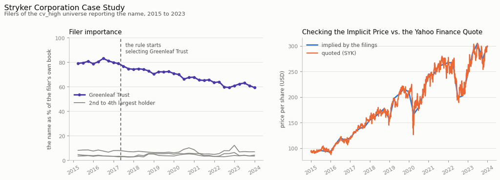

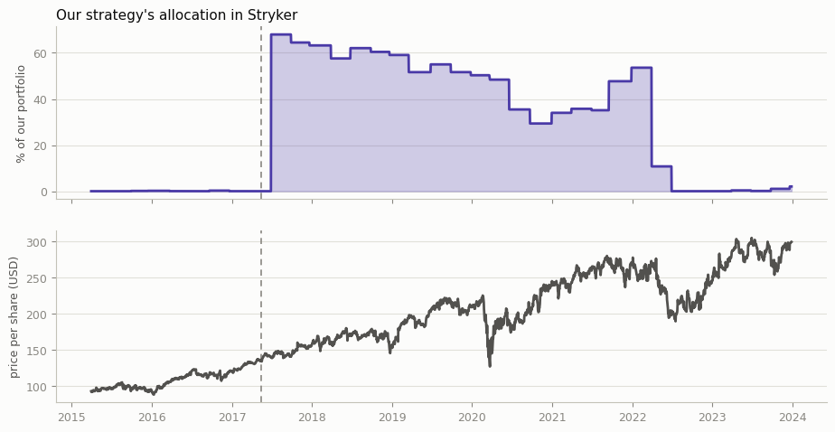

```python
# The universe the headline strategy runs on, so this is not a curiosity in a corner of the grid: it is a
# feature of the result being presented
RULE, CUSIP = BEST['rule'], '863667101'
A, B = '2015-01-01', '2023-12-31'

close = pd.read_parquet(DATA_FINAL / 'spx_close.parquet')
cmap  = pd.read_parquet(DATA_FINAL / 'spx_cusip.parquet')

h   = pd.read_parquet(DATA_FINAL / f'13f_holdings_universe_{RULE}.parquet',
                      columns=['cik','ref_date','vintage_date','cusip','value','sshprnamt'])
tot = h.groupby(['cik','ref_date','vintage_date'])['value'].sum().rename('book')

sk = h.loc[h['cusip'].eq(CUSIP)].merge(tot, on=['cik','ref_date','vintage_date'])
sk = sk.sort_values('vintage_date').drop_duplicates(['cik','ref_date'], keep='last')
sk['w']  = sk['value'] / sk['book']
sk['px'] = sk['value'] / sk['sshprnamt'].where(sk['sshprnamt'].gt(0))
sk = sk.loc[sk['ref_date'].between(A, B)]

# The four filers with the largest position in the name, ranked inside each quarter
rank = sk.sort_values(['ref_date','w'], ascending=[True, False]).groupby('ref_date').head(4).copy()
rank['place'] = rank.groupby('ref_date').cumcount() + 1
top = rank.pivot(index='ref_date', columns='place', values='w') * 100

# The holdings file carries every filer the rule ever picked, so the largest holder shows up before the rule
# started selecting it. The date it was first selected is what the factor actually reacts to
univ   = pd.read_parquet(DATA_INT / f'13f_cik_universe_{RULE}.parquet')
who    = rank.loc[rank['place'].eq(1), 'cik'].mode().iat[0]
enters = univ.loc[univ['cik'].eq(who), 'vintage_date'].min()

# The same filer holds first place in every quarter of the window, so it can be named rather than described
names = pd.read_parquet(DATA_INT / '13f_total.parquet', columns=['cik','filingmanager_name']).dropna().drop_duplicates('cik').set_index('cik')['filingmanager_name']
label = str(names.get(who, who)).title()

# The ticker the mapping gives this cusip, so the filed price can be put next to the quoted one
tick = cmap.loc[:, (cmap == CUSIP).any()].columns[0]
yh   = close[tick].dropna()

fig, ax = plt.subplots(1, 2, figsize=(13, 4.2), facecolor='#fcfcfb')

ax[0].plot(top.index, top[1], lw=2.4, marker='o', ms=4, color=COLOUR['centrality'], label=label, zorder=4)
for p in [2, 3, 4]:
    ax[0].plot(top.index, top[p], lw=1.4, color=INK['muted'], zorder=3,
               label='2nd to 4th largest holder' if p == 2 else None)

ax[0].axvline(enters, lw=1.2, ls=(0, (4, 3)), color=INK['secondary'], zorder=5)
ax[0].annotate(f'the rule starts\nselecting {label}', (enters, 96), xytext=(8, 0), textcoords='offset points',
               va='top', fontsize=8.5, color=INK['secondary'])

ax[0].set_ylim(0, 100)
ax[0].set_ylabel("the name as % of the filer's own book", fontsize=9, color=INK['secondary'])
ax[0].set_title('Filer importance', loc='left', fontsize=11, color=INK['primary'])
ax[0].legend(frameon=False, fontsize=9, labelcolor=INK['secondary'], loc='center left')

# A unit mistake would put the implied price at 0.095 or at 95,000 rather than where the stock traded
q = sk.groupby('ref_date')['px']
ax[1].fill_between(q.median().index, q.quantile(.1), q.quantile(.9), color=COLOUR['net_buying'], alpha=0.18, zorder=2)
ax[1].plot(q.median().index, q.median(), lw=2.2, color=COLOUR['net_buying'], label='implied by the filings', zorder=3)
ax[1].plot(yh.loc[A:B].index, yh.loc[A:B], lw=1.8, color=COLOUR['breadth_change'], label=f'quoted ({tick})', zorder=4)

ax[1].set_ylabel('price per share (USD)', fontsize=9, color=INK['secondary'])
ax[1].set_title('Checking the Implicit Price vs. the Yahoo Finance Quote', loc='left', fontsize=11, color=INK['primary'])
ax[1].legend(frameon=False, fontsize=9, labelcolor=INK['secondary'], loc='upper left')

for a in ax:
    a.set_facecolor('#fcfcfb')
    a.grid(axis='y', color=INK['grid'], lw=0.8)
    a.set_axisbelow(True)
    a.tick_params(colors=INK['muted'], labelsize=9)
    a.tick_params(axis='x', rotation=30)
    for s in ('top','right'): a.spines[s].set_visible(False)
    for s in ('bottom','left'): a.spines[s].set_color(INK['axis'])

fig.suptitle(f'{nm.get(CUSIP).title()} Case Study', x=0.007, y=0.99, ha='left',
             fontsize=13, color=INK['primary'])
fig.text(0.007, 0.925, f'Filers of the {RULE} universe reporting the name, {A[:4]} to {B[:4]}',
         ha='left', fontsize=9.5, color=INK['secondary'])
fig.subplots_adjust(top=0.80)
plt.savefig(DATA_FINAL / 'stryker_cause.png', dpi=150, bbox_inches='tight', facecolor='#fcfcfb')

# What the factor then did to the book. Two stacked panels rather than two y axes on one chart: with two scales
# the relative position of the curves is whatever the scales were chosen to make it
pos = w[CUSIP].loc[:B] * 100

fig, ax = plt.subplots(2, 1, figsize=(11, 5.4), sharex=True, facecolor='#fcfcfb')

ax[0].fill_between(pos.index, pos, color=COLOUR['centrality'], alpha=0.25, zorder=2)
ax[0].plot(pos.index, pos, lw=2, color=COLOUR['centrality'], zorder=3)
ax[0].set_ylabel('% of our portfolio', fontsize=9, color=INK['secondary'])
ax[0].set_title("Our strategy's allocation in Stryker", loc='left', fontsize=11, color=INK['primary'])

p = yh.loc[pos.index.min():B]
ax[1].plot(p.index, p, lw=2, color=INK['secondary'], zorder=3)
ax[1].set_ylabel('price per share (USD)', fontsize=9, color=INK['secondary'])

for a in ax:
    a.axvline(enters, lw=1.2, ls=(0, (4, 3)), color=INK['muted'], zorder=1)
    a.set_facecolor('#fcfcfb')
    a.grid(axis='y', color=INK['grid'], lw=0.8)
    a.set_axisbelow(True)
    a.tick_params(colors=INK['muted'], labelsize=9)
    for s in ('top','right'): a.spines[s].set_visible(False)
    for s in ('bottom','left'): a.spines[s].set_color(INK['axis'])

fig.subplots_adjust(top=0.88, hspace=0.18)
plt.savefig(DATA_FINAL / 'stryker_position.png', dpi=150, bbox_inches='tight', facecolor='#fcfcfb')

con_sk = contributions(w, cost=COST, ret=ret, freq='YE')[CUSIP]

print(f"\n  {label}: {top[1].mean():.0f}% of its own book in the name, against {top[[2,3,4]].to_numpy().mean():.1f}% for the next three")
print(f"  the rule first selects it on {enters.date()}, and the factor goes from {0.009:.3f} to near 1 the year after")
print(f"  price implied by the filings: median {sk['px'].median():.2f} | quoted: median {yh.loc[A:B].median():.2f}")
print(f"  our portfolio: peak {pos.max():.1f}% | median {pos.loc['2017':'2021'].median():.1f}% between 2017 and 2021")
print(f"  it contributed {con_sk.sum():+.3f} of the initial capital, {con_sk.sum()/5.866*100:.1f}% of everything the strategy made")
```

## Next Steps

We close this document with the prioritary three next steps:

### 1. Deal with Survivorship Bias

As discussed, even though we are able to reconstruct the S&P 500 index over time with good precision, even by mapping CUSIPs to tickers, we've seen that Yahoo Finance does not hold price information for merging or failing companies, thus introducing survivorship bias in our strategy as we simply do not consider feasible to invest in companies without price quotes. This is in my opinion the number one weakness with this case study, as could be solved if we had access to a more reliable and complete platform, such as BBG for example.

### 2. Create the correct centrality measure

I've argued why we have to take the absolute value of the $v$ vector when building the centrality vector. The problem is that working with the absolute value changes the interpretation. If we looked at the non-absolute value (and assuming there were no sign changes, which was what led us to do this in the first place), the two ends of the factor would be the two sides of the same disagreement: stocks the dominant group of managers overweights relative to the average, and stocks it underweights. Stocks near zero are the ones every manager sizes alike. By taking the magnitude we lose that direction, and only compare stocks where managers agree against stocks where they disagree, whichever way. The loss is not only interpretive: $|v|$ is folded, so a decile sort on it reads flat even if the signed axis predicts returns linearly, which means the D10−D1 spread reported above says nothing about the signed version. I couldn't solve this problem at first, and hence why I used absolute values, but I do believe that implementation would do better than our current one.

The main current difficulty is that in some points, the SVD solution changes signs, for instance, think of 3 stocks at 5 dates and its factor values:

|  | A | B | C |
| --- | --- | --- | --- |
| D1 | −1 | 0 | 1 |
| D2 | −1 | 0 | 1 |
| D3 | −1 | 1 | 0 |
| D4 | 1 | −1 | 0 |
| D5 | −1 | 1 | 0 |

Note that at D4, the relative position was exactly the same as both D3 and D5, but the sign change would induce us to make a wrong rebalancing. At first, I tried to work with some kind of autocorrelation between the factor vectors. If a vector from one period to the other has a correlation of exactly -1, then it was almost certainly an inversion, and we could multiply the current vector by -1 to keep it consistent. However, especially around filling deadlines, the factors would indeed change, so a sign change could happen but with correlation far from -1. Thus, I prefered to stick with the absolute value implementation, but would like to think of a new way of solving this problem to work with the real centrality factor.

### 3. Solve Concentration

We've seen that the strategy allocates very high shares of the portfolio in bets with high values of the centrality factor. I have used a cap at the factor value at 3, but even with this cap we've seen large bets in some stocks. I believe this may help us reduce the volatility of the strategy, while not losing much depending on how much (and following which ruling) we cap the maximum portfolio allocation in each stock.